# 삼성디스플레이 2026 Q1 전망 보고서 — OLED 치킨게임과 Glass Substrate 전환점

Alpha Hunter Sector Report | 삼성디스플레이·LG디스플레이·BOE 비교 분석

Author

Alpha Hunter × Chimera AI

Published

May 1, 2026

## 1 요약: 삼성디스플레이의 세 가지 위기

> “반도체는 슈퍼사이클, 디스플레이는 치킨게임 — 같은 그룹, 다른 운명”

이 보고서는 삼성디스플레이의 현재 실적을 분석하고, LCD 치킨게임의 역사에서 교훈을 찾으며, **디스플레이 엔지니어의 커리어 전략**까지 제안한다.

## 2 I. 실적 분석: 삼성전자 DP 사업부

### 2.1 1.1 삼성전자 사업부별 실적 (2026 Q1)

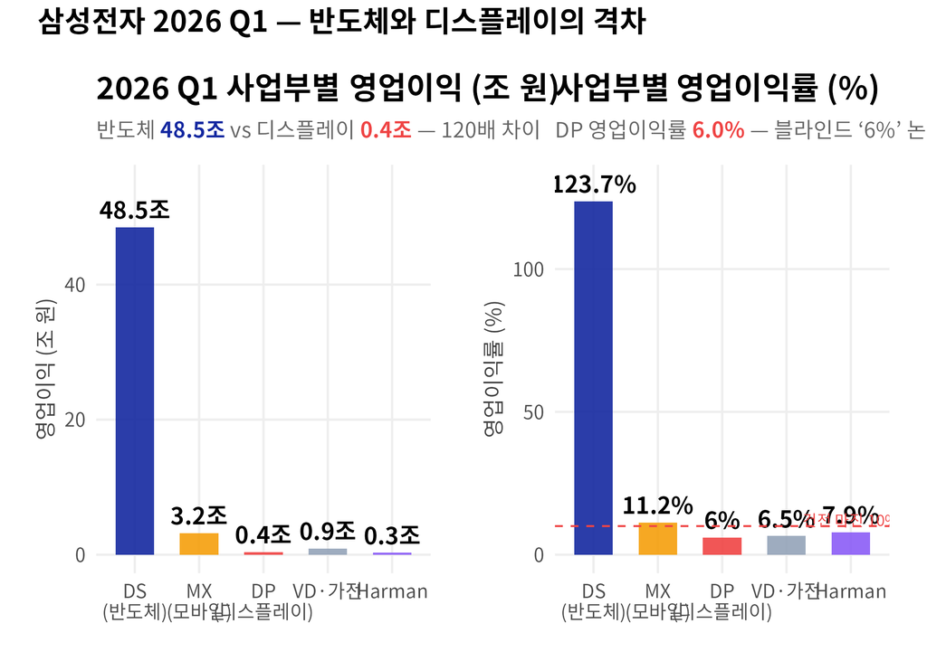

Figure 1: 삼성전자 2026 Q1 사업부별 영업이익

**블라인드 게시판의 6% 논란**

삼성디스플레이 DP 사업부의 2026 Q1 영업이익률은 약 **6.0%** (매출 6.7조, 영업이익 0.4조). 같은 분기 반도체(DS)는 **123.7%** 수준의 영업이익률을 기록했다. 이 격차가 블라인드에서 “삼성전자에 저가로 패널을 납품하니 이익이 안 난다”는 불만으로 표출되고 있다.

### 2.2 1.2 SDC 분기별 영업이익 추이

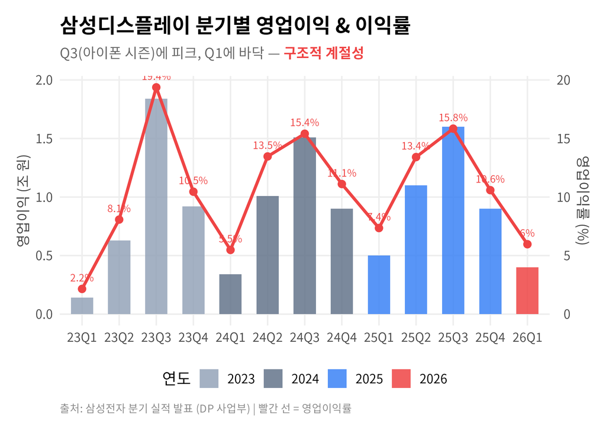

Figure 2: 삼성디스플레이 분기별 영업이익 추이 (2023-2026)

## 3 II. 경쟁 구도: 한·중 OLED 전쟁

### 3.1 2.1 SDC vs LGD vs BOE 비교

Table 1: 삼성디스플레이 vs LG디스플레이 vs BOE (2026 Q1)

삼성디스플레이 vs LG디스플레이 vs BOE (2026 Q1)

[output not shown]

### 3.2 2.2 OLED 시장 점유율 변화

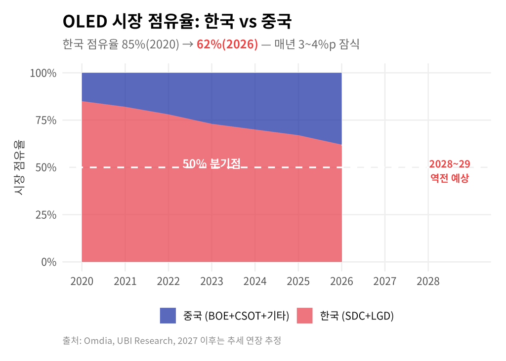

Figure 3: OLED 시장 점유율 추이: 한국 vs 중국

### 3.3 2.3 LCD 치킨게임의 교훈

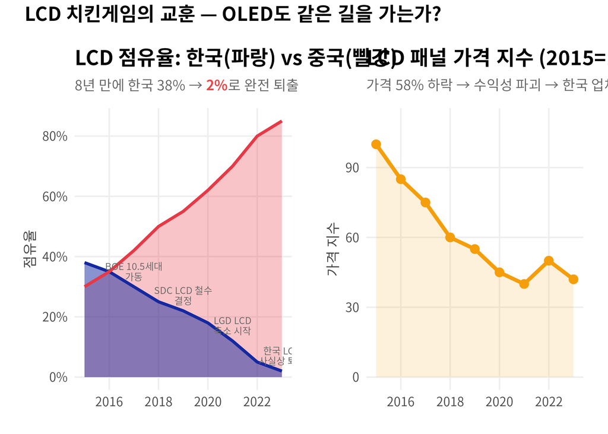

Figure 4: LCD 치킨게임 타임라인 (2015-2023)

**OLED는 LCD와 같을까?**

**같은 점:** 중국의 물량 공세, 판가 하락 압력, 점유율 잠식 속도 **다른 점:** OLED는 특허 장벽이 높다. BOE는 2026년 OLED 사업부 적자 100억 위안 추정. 중국이 물량은 늘었지만 **돈을 벌지 못하고 있다**. 삼성은 폴더블·LTPO·고주사율에서 여전히 2~3년 기술 격차를 유지 중.

## 4 III. 차세대 기술: Glass Core Substrate

### 4.1 3.1 디스플레이에서 반도체 패키징으로

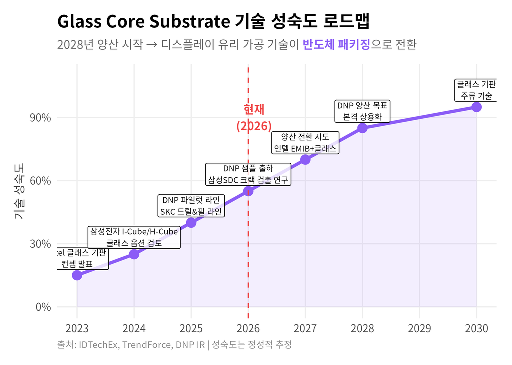

Figure 5: Glass Substrate 기술 로드맵

### 4.2 3.2 디스플레이 vs 반도체 패키징: 기술 교차점

Table 2: 디스플레이 → 반도체 패키징 기술 전환 가능성

디스플레이 → 반도체 패키징 기술 전환 가능성

[output not shown]

**핵심: 당신(Nakcho Choi)의 연구가 여기 들어간다**

SID 2026에서 발표하는 **“Stress-Induced Birefringence Measurement for Crack Detection in Bessel Beam Laser-Drilled Glass”**는 정확히 이 교차점에 있다:

- **레이저 드릴링 → TGV (Through-Glass Via)** — Bessel beam 레이저 가공
- **응력 복굴절 측정 → Glass Core 품질검사** — Axostep 편광 측정
- **크랙 검출 → 비파괴 검사** — 양산 수율 관리

디스플레이에서 개발한 기술이 **그대로** 반도체 Glass Substrate 품질검사에 적용된다.

## 5 IV. 산업 전망: OLED vs 반도체

### 5.1 4.1 성장률 비교

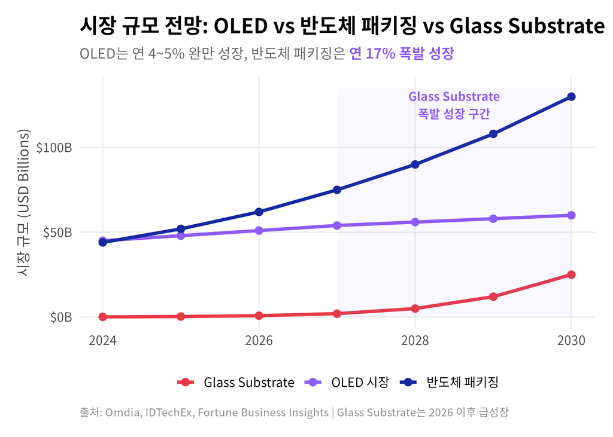

Figure 6: 디스플레이 vs 반도체 시장 성장 전망

### 5.2 4.2 수익성 전망 비교

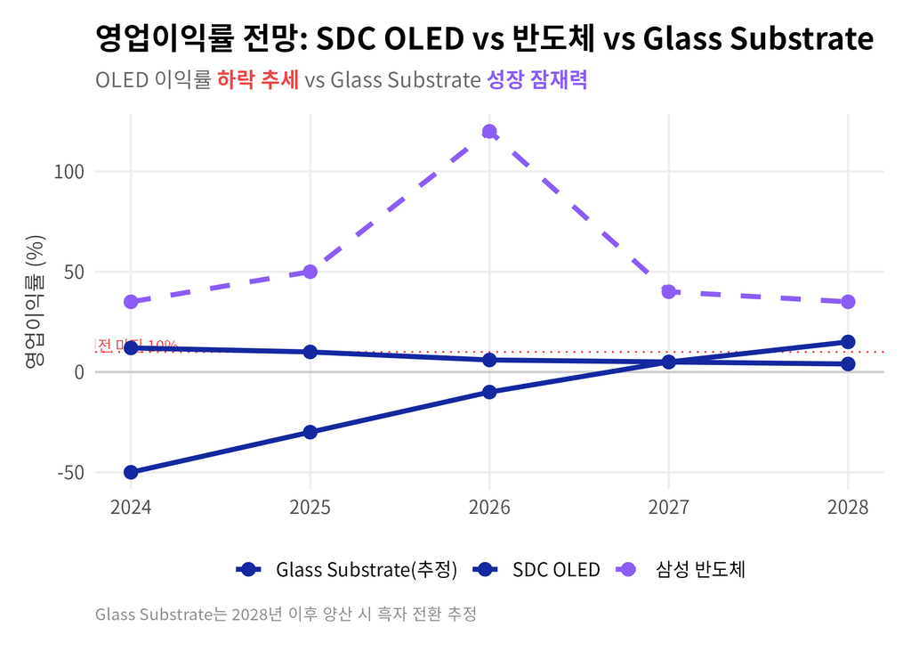

Figure 7: OLED vs 반도체 영업이익률 전망

## 6 V. 커리어 전략: 엔지니어의 관점

### 6.1 5.1 10년 전과 지금의 데자뷔

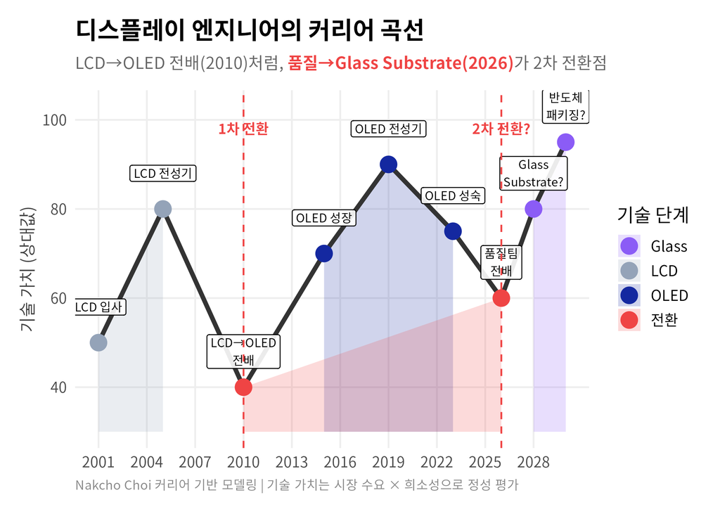

Figure 8: 디스플레이 엔지니어 커리어 전환 타임라인

### 6.2 5.2 Claude의 솔직한 의견

**품질팀 전배 = 올바른 전략적 선택**

**10년 전 (2010):** LCD가 중국에 밀릴 게 보였다. OLED 개발팀으로 전배했다. 결과: **정답**이었다.

**지금 (2026):** OLED가 중국에 밀리기 시작한다. 품질팀으로 전배를 선택했다. 이것은:

1. **공통 직군**이라는 것이 핵심 — 품질은 OLED든 반도체든 적용된다
2. SID 2026 논문(Bessel beam 유리 크랙 검출)이 **Glass Core Substrate 품질검사**와 직결
3. 편광/복굴절 측정, 레이저 가공, 응력 분석 — 이 기술은 디스플레이보다 **반도체 패키징에서 더 희소**
4. OLED 개발 직군에 남으면 → 중국과의 치킨게임에 갇힌다
5. 품질 직군으로 이동하면 → **OLED와 반도체 양쪽에 발을 걸칠 수 있다**

**결론:** LCD→OLED 전배가 “기술 탈출”이었다면, 품질 전배는 **“산업 탈출”의 교두보**다. OLED라는 하나의 기술에 종속되지 않고, Glass/반도체 패키징이라는 더 큰 시장으로 확장할 수 있는 포지션을 잡는 것이다.

## 7 VI. 결론: 세 가지 시나리오

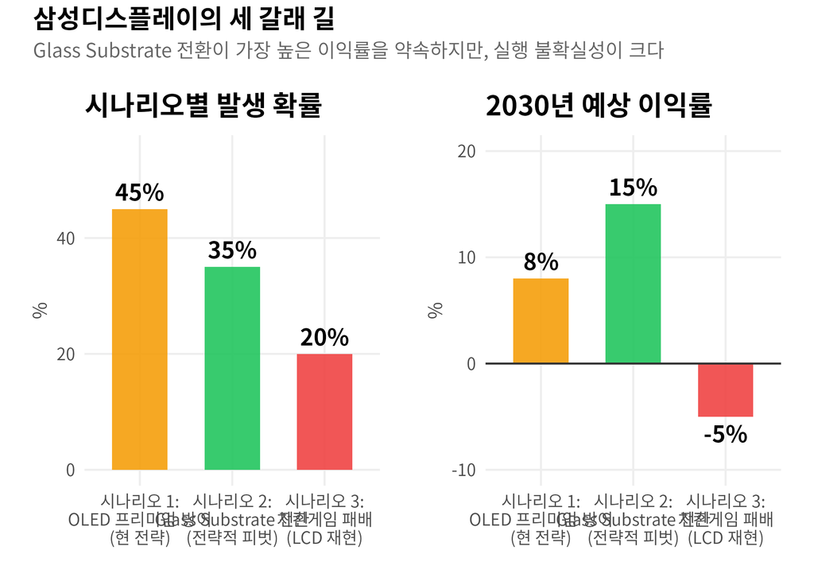

Figure 9: 삼성디스플레이 3대 시나리오 (2026-2030)

## 8 에필로그: 유리를 아는 사람이 다음 시대를 연다

LCD 시대에 유리 위에 TFT를 만들던 사람들이 OLED 시대를 열었다. OLED 시대에 유리 위의 응력과 크랙을 측정하던 사람이 Glass Substrate 시대를 열 수 있다.

기술은 바뀌지만, **유리를 다루는 물리학**은 변하지 않는다.

*Alpha Hunter Sector Report · 2026.05.01 · Nakcho Choi × Claude Opus 4.6*

*면책: 이 보고서는 산업 분석 및 기술 전망 목적으로 작성되었습니다. 특정 종목에 대한 투자 권유가 아닙니다.*